# Question 2 — US Baby Names (1910–2014)

Student 25052977

19 June 2026

## The brief

For a toy-design agency: which names have been most popular over time, how *persistent* that popularity is, and the surges that follow culture (TV characters, singers, songs). The agency wants this to guide which character names to put on toys.

## Most popular names by decade

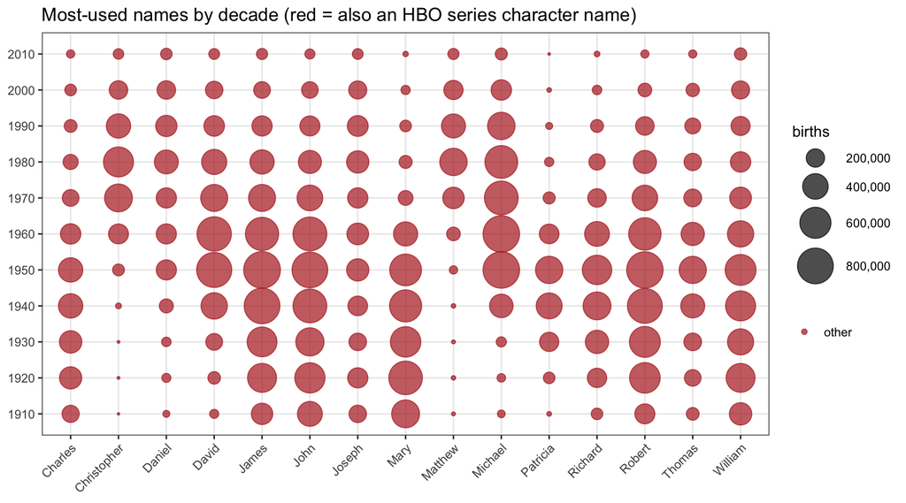

The all-time favourites are long-runners that rise and fade over the decades. Several of them also turn up as series character names (red), but that is mostly because common names get reused for characters, so the popularity came first and the shows followed.

## How persistent is popularity?

For each year I take the 25 most popular names per gender and check how similar their ranking still is three years later (Spearman rho).

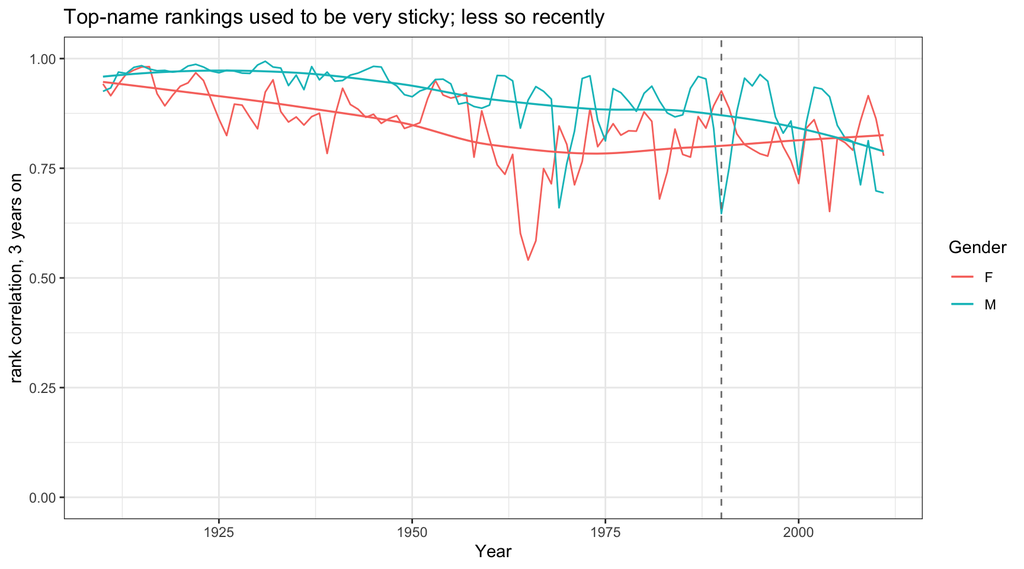

Persistence is high throughout (rho mostly above 0.8): a year’s top names are usually still near the top three years later. But it has softened: average rho is 0.89 before 1990 versus 0.83 from 1990 on. So the agency’s hunch is right: names churn a little faster now than they used to.

## Surges that follow culture

These names at least tripled in a single year. Where a Billboard artist with the same first name was charting in the two years before the spike, I flag it as a likely cause.

| Name | Gender | Year | prev_count | count | growth | billboard_artist |
| --- | --- | --- | --- | --- | --- | --- |
| Jaime | F | 1976 | 897 | 7836 | 8.7 | NA |
| Cheryl | F | 1943 | 550 | 2875 | 5.2 | NA |
| Jenna | F | 1984 | 1148 | 5877 | 5.1 | NA |
| Mariah | F | 1991 | 1086 | 5190 | 4.8 | Mariah Carey |
| Ethan | M | 1989 | 872 | 4053 | 4.6 | NA |
| Selena | F | 1995 | 865 | 3804 | 4.4 | Selena |
| Shaun | M | 1977 | 585 | 2575 | 4.4 | Shaun Cassidy |
| Ramona | F | 1928 | 520 | 2229 | 4.3 | NA |
| Brenda | F | 1939 | 646 | 2736 | 4.2 | NA |
| Darrin | M | 1965 | 784 | 3254 | 4.2 | NA |
| Gael | M | 2012 | 645 | 2733 | 4.2 | NA |
| Jase | M | 2013 | 1100 | 4539 | 4.1 | NA |
| Brett | M | 1958 | 606 | 2119 | 3.5 | NA |
| Jeremy | M | 1969 | 609 | 2074 | 3.4 | NA |
| Lizbeth | F | 2002 | 754 | 2553 | 3.4 | NA |

The matches are telling: the **Mariah** spike (1991) lands right after Mariah Carey’s chart debut, **Selena** surges in the mid-90s, and similar music-driven jumps show up elsewhere. This is the pattern the agency cares about. A name can ride a hit, but (from the persistence result) it will likely fade just as fast, so a toy tie-in should be timed to the surge rather than treated as a lasting trend.

## Notes

Counts are national (summed over states). The bubble uses the 15 highest-count names overall; persistence uses the top 25 per year per gender; the surge cross-reference uses the Billboard `charts.rds` data. HBO character names are used to flag character overlaps. The brief’s 1974 *Katina* example is the same kind of TV-driven spike, from a soap-opera character that year.